# 20181_M2.855_PEC2-Enunciado

[figure not shown]

M2.855 · Modelos avanzados de minería de datos · PEC2

2018-1 · Máster universitario en Ciencia de datos (Data science)

Estudios de Informática, Multimedia y Telecomunicación

Alumno: **Fernando Antonio Barbeiro Campos** - fbarbeiro@uoc.edu

# PEC 2: Métodos no supervisados

A lo largo de esta práctica veremos como aplicar distintas técnicas no supervisadas así como algunas de sus aplicaciones reales:

1. **Clustering clásico**: k-means y la regla del codo.
2. **Clustering con formas y feature engineering**.
3. **Reducción de dimensionalidad**: PCA y t-SNE.
4. **Aplicación**: agrupación de documentos.

Para ello vamos a necesitar las siguientes librerías:

```python
import random

import numpy as np
import pandas as pd
from sklearn import cluster      # Algoritmos de clustering.
from sklearn import datasets     # Crear datasets.

# Visualizacion.
import matplotlib.pyplot as plt
import seaborn as sns
from sklearn.cluster import KMeans
from sklearn.cluster import DBSCAN
from scipy.cluster.hierarchy import linkage
from scipy.cluster.hierarchy import dendrogram, leaves_list
from sklearn.preprocessing import MinMaxScaler

%matplotlib inline
```

## 1. Clustering clásico: k-means y la regla del codo (2 puntos)

Vamos a generar un dataset compuesto por $n$ nubes de puntos, donde $n$ será un número aleatorio entre 2 y 4, usando el módulo `datasets` de scikit-learn.

```
Hay 1500 puntos en 2 dimensiones (repartidos en 4 clusters)
```

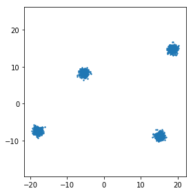

```python
N_SAMPLES = 1500
MIN_CLUSTERS = 2
MAX_CLUSTERS = 4
X, y = datasets.make_blobs(n_samples=N_SAMPLES, # Cuantos puntos
                           n_features=2,        # Cuantas dimensiones
                           centers=random.randint(MIN_CLUSTERS, MAX_CLUSTERS),
                           center_box=(-20, 20),
                           cluster_std=.6)
print('Hay {} puntos en {} dimensiones (repartidos en {} clusters)'.format(X.shape[0], X.shape[1], y.max() + 1))
fig, ax = plt.subplots(1, 1, figsize=(4, 4))
ax.scatter(X[:,0], X[:,1], s=2)
ax.axis('equal')
plt.tight_layout()
```

Una técnica para estimar $k$ es, como se explica en la teoría:

> Los criterios anteriores (minimización de distancias intra grupo o maximización de distancias inter grupo) pueden usarse para establecer un valor adecuado para el parámetro k. Valores k para los que ya no se consiguen mejoras significativas en la homogeneidad interna de los segmentos o la heterogeneidad entre segmentos distintos, deberían descartarse.

Lo que popularmente se conocer como *regla del codo*.

Primero es necesario calcular la suma de los errores cuadráticos ([*SSE*](https://bl.ocks.org/rpgove/0060ff3b656618e9136b)) que consiste en la suma de todos los errores (distancia de cada punto a su centroide asignado) al cuadrado.

$$SSE = \sum_{i=1}^{K} \sum_{x \in C_i} euclidean(x, c_i)^2$$

Donde $K$ es el número de clusters a buscar por *k-means*, $x \in C_i$ son los puntos que pertenecen a i-ésimo cluster, $c_i$ es el centroide del cluster $C_i$ (al pertenece el punto $x$), y $euclidean$ es la [distancia euclídea](https://en.wikipedia.org/wiki/Euclidean_distance).

Este procedimiento realizado para cada posible valor $k$, resulta en una función monótona decreciente, donde el eje $x$ representa los distintos valores de $k$, y el eje $y$ el $SSE$. Intuitivamente se podrá observar un significativo descenso del error, que indicará el valor idóneo de $k$.

**Se pide realizar la representación gráfica de la regla del codo junto a su interpretación, utilizando la librería `matplotlib` y la implementación en scikit-learn de [*k-means*](http://scikit-learn.org/stable/modules/generated/sklearn.cluster.KMeans.html).**

**Implementación:** cálculo y visualización de la regla del codo.

```
[183103.01637916063, 77224.129076026]
```

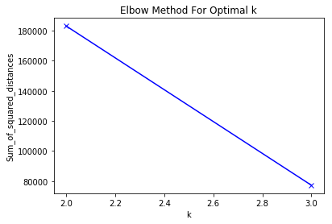

```python
# Hice 3 implementaciones (una siendo un test con un valor más amplio de MAX_CLUSTER)
# voy a explicar todo en el análisis

Sum_of_squared_distances = []

def calculate_and_plot_elbow () :
    K = range(MIN_CLUSTERS, MAX_CLUSTERS)
    for k in K:
        km = KMeans(n_clusters=k)
        km = km.fit(X)
        Sum_of_squared_distances.append(km.inertia_)

    print(Sum_of_squared_distances)
    plot_elbow(K)

def plot_elbow (K) :
    plt.plot(K, Sum_of_squared_distances, 'bx-')
    plt.xlabel('k')
    plt.ylabel('Sum_of_squared_distances')
    plt.title('Elbow Method For Optimal k')
    plt.show()

calculate_and_plot_elbow()
```

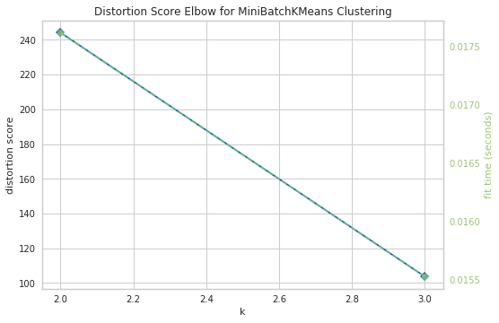

```python
from sklearn.cluster import MiniBatchKMeans

from yellowbrick.cluster import KElbowVisualizer

visualizer = KElbowVisualizer(MiniBatchKMeans(), k=(MIN_CLUSTERS, MAX_CLUSTERS))

visualizer.fit(X)
visualizer.poof()
```

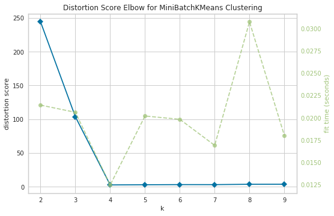

```python
visualizer = KElbowVisualizer(MiniBatchKMeans(), k=(MIN_CLUSTERS, 10))

visualizer.fit(X)
visualizer.poof()
```

**Análisis:** ¿Qué se interpreta en la gráfica? ¿Cómo podría mejorarse la elección de $k$?.

De forma **optativa** se plantea **realizar el apartado anterior con una implementación propia del algoritmo *k-means***.

**[OPCIONAL] Implementación:** algoritmo *k-means* desde cero.

En este caso, con 2 dimensiones, es muy sencillo inferir el número de clusters visualizando los datos. Pero este método es de gran utilidad cuando se cuenta con datos de alta dimensionalidad.

## 2. Clustering con formas y feature engineering (4 puntos)

Pero no todos los datasets son como los del ejercicio anterior. Para esta segunda parte vamos a emplear el siguiente conjunto de datos:

```python
data_circles = ('circles', *datasets.make_circles(n_samples=N_SAMPLES, factor=.5, noise=.05))
```

Donde *data_circles* es una tupla con tres posiciones: el nombre del dataset y los dos valores devueltos por la función que genera el dataset:

```python
datasets.make_circles?
```

```python
data_circles
```

```
('circles', array([[ 0.04010964, -0.40120084],
        [ 1.01023543,  0.14412164],
        [ 0.54778126,  0.9113477 ],
        ...,
        [-0.52549462, -0.84020928],
        [-0.91824195, -0.316363  ],
        [-0.63082922, -0.87631058]]), array([1, 0, 0, ..., 0, 0, 0]))
```

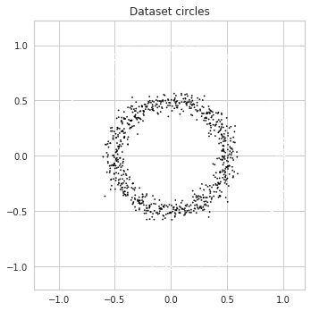

```python
fig, ax = plt.subplots(1, 1, figsize=(5, 5))
ax.scatter(data_circles[1][:,0], data_circles[1][:,1], c=data_circles[2], s=2)
ax.set_title('Dataset {}'.format(data_circles[0]))
plt.tight_layout()
```

### 2 a. Encontrando los clusters con *k-means*

**Implementación:** aplica la regla del codo para decidir el valor de $k$.

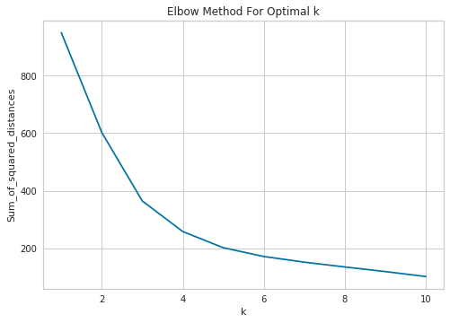

```python
# Repetindo la logica de la misma función que he definido arriba (podría haber optimizado y llamado la misma)
# no lo hice para quedar claro las operaciones aqui
Sum_of_squared_distances_circles = []

def calculate_and_plot_elbow_circles (X) :
    K = range(1, 11)
    for k in K:
        km = KMeans(n_clusters=k)
        km = km.fit(X)
        Sum_of_squared_distances_circles.append(km.inertia_)
    plot_elbow_circles(K)

def plot_elbow_circles (K) :
    plt.plot(K, Sum_of_squared_distances_circles, 'bx-')
    plt.xlabel('k')
    plt.ylabel('Sum_of_squared_distances')
    plt.title('Elbow Method For Optimal k')
    plt.show()

X = data_circles[1]
calculate_and_plot_elbow_circles(X)
```

El valor de K elegido es **K = 4**

**Implementación:** aplica *k-means* con el valor de $k$ elegido.  
Visualiza el resultado en un *scatter plot* representando cada cluster con un color distinto.

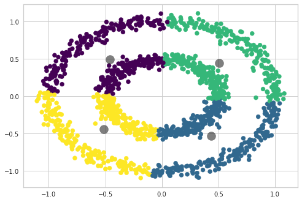

```python
def implemented_ploted_kmeans(X, k=4):
    kmeans = KMeans(n_clusters=k)
    kmeans.fit(X)
    y_kmeans = kmeans.predict(X)

    plt.scatter(X[:, 0], X[:, 1], c=y_kmeans, s=50, cmap='viridis')

    centers = kmeans.cluster_centers_
    plt.scatter(centers[:, 0], centers[:, 1], c='black', s=200, alpha=0.5)

implemented_ploted_kmeans(X)
```

**Análisis:** ¿Qué ha sucedido? Explica los motivos por los que crees que se ha producido ese resultado.

Como estamos usando K-Means, la primera observación es que hemos definido la cuantidad de clusters que tendremos, K = 4. Luego, los 4 centroides son definidos de una manera aleatoria donde quedan dentro del rango de valores de la muestra, pero distantes unos de los otros.

Cada punto que está cerca de uno de los centroides es asignado al grupo del centroide con lo que llaman de "*initial grouping*".

Entonces, encontramos el centro del "*data point*" y movemos el centroide para allí para otra vez asignar todos los puntos de acuerdo con la distancia de cada uno de los centroides. El proceso se repite otra veces.

En mi punto de vista, queda claro visualmente que **habría que haber 2 grupos circulares** en vez de 4. Uno de los **principales inconvenientes de K-Means es su uso del valor medio para el centro del clúster** - entiendo que K-Means no puede manejar esto porque los valores medios de los clusters están muy juntos.

### 2 b. Más allá de K-Means: algoritmos basados en densidad

En este apartado se pide aplicar clustering por densidad como DBSCAN al dataset anterior para poder encontrar los dos clusters iniciales.

**Implementación:** prueba la implementación de [DBSCAN en scikit-learn](http://scikit-learn.org/stable/modules/generated/sklearn.cluster.DBSCAN.html) jugando con los parámetros *eps* y *min_samples* para encontrar las 2 estructuras subyacentes (y *outliers*).

```python
scan = DBSCAN()
scan
# Por defecto, eps=0.5, min_samples=5
```

```
DBSCAN(algorithm='auto', eps=0.5, leaf_size=30, metric='euclidean',
    metric_params=None, min_samples=5, n_jobs=None, p=None)
```

```python
y_scan = scan.fit_predict(X)
y_scan
num_clusters = len(np.unique(y_scan))
print("Numero de clusters:", num_clusters)
```

```
Numero de clusters: 1
```

Obviamente, no es lo que queremos alcanzar con la implementación del DBScan, por lo tanto, propondré una función para jugar con los parámetros y ayudar a encontrar el que mejor encaje:

```python
def apply_dbscan(data, min_cluster=2, min_sample=[1,2,3,4,5], eps=[0.1,0.2,0.3,0.4,0.5,1.0,1.5,2.0]):
    print('Applying dbscan...')
    for i in range(len(min_sample)):
        for j in range(len(eps)):
            scan = DBSCAN(min_samples=min_sample[i], eps=eps[j])
            scan_y = scan.fit_predict(data)
            if(len(np.bincount(scan_y + 1)) > min_cluster):
                print('min_samples', min_sample[i]
                      , 'eps=', eps[j]
                      , 'num_clusters=', len(np.unique(scan_y))
                      , 'clusters=', np.bincount(scan_y + 1)
                     )


apply_dbscan(X)
```

```
Applying dbscan...
min_samples 1 eps= 0.1 num_clusters= 3 clusters= [  0 750 749   1]
min_samples 1 eps= 0.2 num_clusters= 2 clusters= [  0 750 750]
min_samples 2 eps= 0.1 num_clusters= 3 clusters= [  1 750 749]
min_samples 2 eps= 0.2 num_clusters= 2 clusters= [  0 750 750]
min_samples 3 eps= 0.1 num_clusters= 3 clusters= [  1 750 749]
min_samples 3 eps= 0.2 num_clusters= 2 clusters= [  0 750 750]
min_samples 4 eps= 0.1 num_clusters= 3 clusters= [  1 750 749]
min_samples 4 eps= 0.2 num_clusters= 2 clusters= [  0 750 750]
min_samples 5 eps= 0.1 num_clusters= 3 clusters= [  1 750 749]
min_samples 5 eps= 0.2 num_clusters= 2 clusters= [  0 750 750]
```

Elegimos la opción donde *min_samples=2* y *eps=0.1* El primer cluster es por definición formado por *outliers*, luego quedamos con 2 agrupamientos reales.

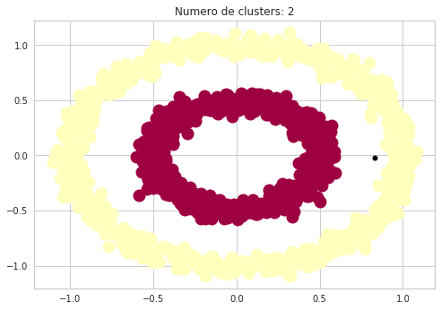

```python
def ploting(X, labels, core_samples_mask):
    unique_labels = set(labels)
    colors = [plt.cm.Spectral(each) for each in np.linspace(0, 1, len(unique_labels))]
    for k, col in zip(unique_labels, colors):
        if k == -1:
            # Black used for noise.
            col = [0, 0, 0, 1]

        class_member_mask = (labels == k)

        xy = X[class_member_mask & core_samples_mask]
        plt.plot(xy[:, 0], xy[:, 1], 'o', markerfacecolor=tuple(col),
                 markeredgecolor='k', markersize=14)

        xy = X[class_member_mask & ~core_samples_mask]
        plt.plot(xy[:, 0], xy[:, 1], 'o', markerfacecolor=tuple(col),
                 markeredgecolor='k', markersize=6)
    n_clusters_ = len(set(labels)) - (1 if -1 in labels else 0)
    plt.title('Numero de clusters: %d'% n_clusters_)
    plt.show()

def my_DBSCAN(eps, min_samples, X):

    db = DBSCAN(eps=eps, min_samples=min_samples).fit(X)
    core_samples_mask = np.zeros_like(db.labels_, dtype=bool)
    core_samples_mask[db.core_sample_indices_] = True
    labels = db.labels_

    ploting(X, labels, core_samples_mask)

my_DBSCAN(0.1, 2, X)
```

**Análisis:** ¿Qué ha sucedido? Explica los motivos por los que crees que se ha producido ese resultado.

Ahora el agrupamiento ha sucedido de la manera adecuada que no hemos logrado antes - con 2 grupos que realmente representan los círculos (además de los puntos negros que son ruidos).

Tres observaciones antes de explicar los motivos:

- Los algoritmos de DBSCAN son visiblemente más lentos que K-means;
- Un poco más dificil encontrar los parámetros correctos;
- Dependen de la distancia euclidiana - que pueden resultar en clusters muy dispersos para datasets grandes.

En un resumen de mi explicación de los motivos:

DBSCAN empieza con un punto inicial arbitrario y los puntos alrededor se extraen utilizando una distancia épsilon ε. Si hay una cantidad suficiente de puntos en los alrededores (*minPoints*), entonces el proceso de agrupación en clúster comienza y el punto de datos actual se convierte en el primer punto en la nueva agrupación.

Este proceso de los pasos se repite hasta que todos los puntos del clúster se determinan, es decir, todos los puntos dentro del vecindario ε del clúster se han visitado y etiquetado.

Obviamente, los puntos que no pueden ser etiquetados en un determinado grupo son los *outliers* (o ruido).

Por aquí, una imagen que representa de manera iterativa una ejecución (obviamente, no del ejercicio en cuestión, un ejemplo de Internet cualquiera):

[figure not shown]

### 2 c. Más allá de K-Means: algoritmos jerárquicos

En este apartado se pide visualizar mediante un [dendrograma](https://en.wikipedia.org/wiki/Dendrogram) la construcción progresiva de los grupos mediante un algoritmo jerárquico aglomerativo (estrategia *bottom-up*). Con ello se pretende encontrar un método gráfico para entender el comportamiento del algoritmo y encontrar los dos clusters.

**Implementación:**  
prueba la implementación de [clustering jerárquico de scipy](https://docs.scipy.org/doc/scipy/reference/cluster.hierarchy.html) probando distintos [criterios de enlace o *linkage*](https://en.wikipedia.org/wiki/Hierarchical_clustering#Linkage_criteria) permimtiendo identificar los clusters subyacentes (mostrando su resultado) y su dendrograma.

```python
Z = linkage(X)
```

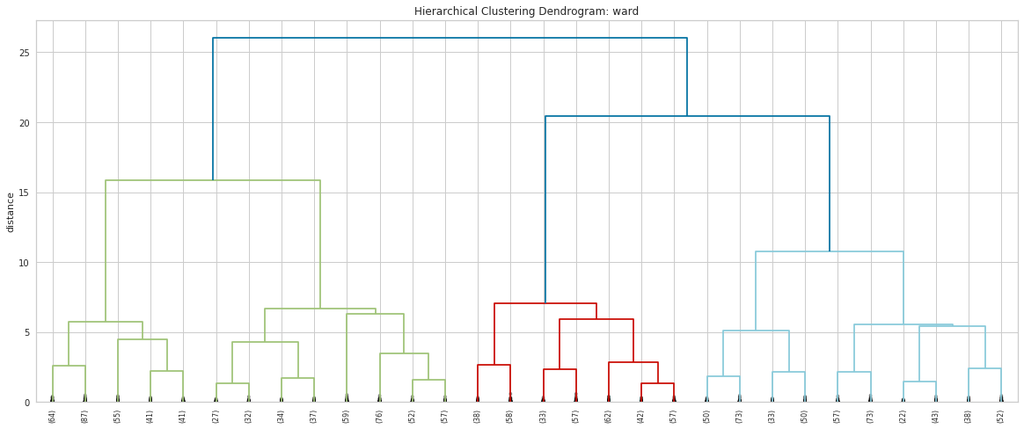

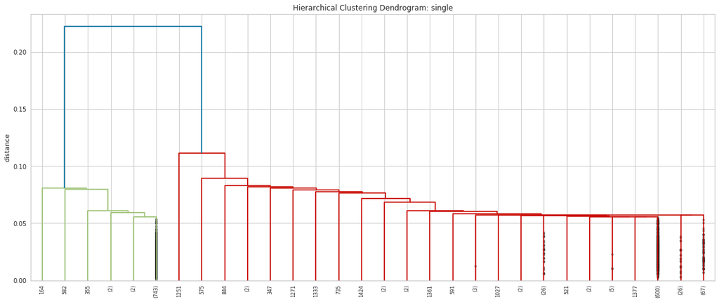

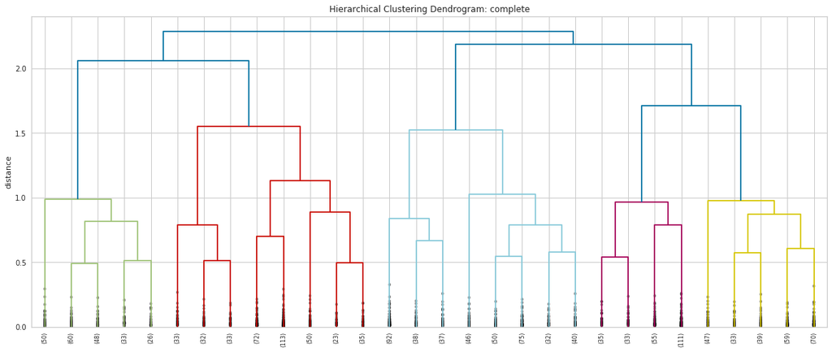

```python
def cluster_and_plot(X, my_linkage):

    Z = linkage(X, my_linkage) # https://en.wikipedia.org/wiki/Ward%27s_method

    plt.figure(figsize=(20, 8))
    title = 'Hierarchical Clustering Dendrogram: ' + my_linkage
    plt.title(title)
    plt.ylabel('distance')
    dendrogram(
        Z,
        truncate_mode='lastp',  # show only the last p merged clusters
        leaf_rotation=90.,  # rotates the x axis labels
        leaf_font_size=8.,  # font size for the x axis labels
        show_contracted=True  # to get a distribution impression in truncated branches
    )
    plt.show()

def test_all_hierarchy(X):
    cluster_and_plot(X, 'ward')
    cluster_and_plot(X, 'single')
    cluster_and_plot(X, 'complete')

test_all_hierarchy(X)
```

**Análisis:** Interpreta el dendrograma y comenta qué criterio de enlace se ha comportado mejor. ¿Por qué?

Desde mi punto de vista, el que más encajaría con el comportamiento esperado sería el que contiene *linkage criteria* = **single**, especialmente porque ha sido el mismo que ha creado dos clusters distintos como el resultado de la *matriz Z* como tendría que ser - siguiendo el razonamiento del ejercicio 2b.

**Análisis:** ¿Qué ha sucedido? Explica los motivos por los que crees que se ha producido ese resultado.

Analizando el **Single-linkage clustering** supongo que como el mismo se basa en juntar agrupaciones en forma ascendente (agrupación por aglomeración), el criterio ha logrado de agrupar los círculos de manera adecuado por su inherente característica de producir agrupaciones largas y delgadas en las que los elementos cercanos de la misma agrupación tienen pequeñas distancias. Quizás, si fuera necesaria la definición de clases que podrían subdividir los datos de manera útil, posiblemente el criterio no sería el indicado.

### 2 d. *Feature engineering* y agrupamiento

Algunos de los algoritmos anteriores se basan en unas suposiciones que no cumplían en el dataset. Muchas veces en lugar de optar por algoritmos más complejos o que requieren mayor cómputo, se pueden transformar los datos para poder aplicar con éxito técnicas más simples. Esto es un claro ejemplo de *feature engineering*.

**Implementación:** transforma los puntos anteriores del dataset a un nuevo espacio de 2 dimensiones:

- Radio, o distancia al punto (0,0)
- Ángulo,con respecto al vector (1,0)

Para que todas las dimensiones tengan el mismo peso, además vamos a [normalizarlas entre 0 y 1 de acuerdo a su máximo y mínimo](http://scikit-learn.org/stable/modules/generated/sklearn.preprocessing.MinMaxScaler.html).  
Visualizar los puntos del "nuevo" dataset.

```python
def normalize(df):

    scaler = MinMaxScaler(feature_range=(0, 1))
    dates_scaled = scaler.fit_transform(df)

    return dates_scaled



x,y = X[:,0], X[:,1]
r = np.sqrt(x**2+y**2)
t = np.arctan2(y,x)
d = {'radio': r, 'angulo': t}
df = pd.DataFrame(data=d)
df = normalize(df)
df
```

```
array([[0.05922321, 0.26551239],
       [0.82683155, 0.5225412 ],
       [0.88010812, 0.66403691],
       ...,
       [0.79020071, 0.16056382],
       [0.76558412, 0.05218295],
       [0.90056102, 0.15020105]])
```

**Análisis:** ¿Qué crees que sucederá al aplicar los anteriores algoritmos en este "nuevo" dataset?

Creo que con el feature engineering algunas transformaciones más sencillas que no funcionaban apropiadamente en los ejemplos anteriores ahora debería funcionar, por ejemplo, K-Means. O sea, el desempeño de los algoritmos de agrupamiento tendrán una subida.

**Implementación:** aplica cada uno de los algoritmos de agrupamimento anteriores que no hayan podido localizar adecuadamente los dos clusters originales para tratar de encontrarlos en este "nuevo" espacio. Ajusta los parámetros necesarios para facilitar su detección.  
Para cada algoritmo, visualiza los clusters encontrados en 2 imágenes:

- En el "nuevo" espacio (radio y ángulo).
- En el espacio original (posición x e y), pero NO con las etiquetas (pertenencia al cluster) obtenidas al aplicar los algoritmos sobre el dataset original, sino con las etiquetas obtenidas al realizar el clustering en el "nuevo" espacio. A ver si así se consiguen solventar los problemas iniciales.

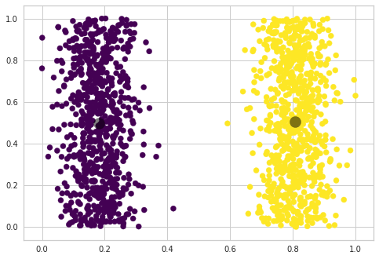

```python
implemented_ploted_kmeans(df, 2)
```

```
Applying dbscan...
min_samples 1 eps= 0.1 num_clusters= 2 clusters= [  0 750 750]
min_samples 1 eps= 0.2 num_clusters= 2 clusters= [  0 750 750]
min_samples 2 eps= 0.1 num_clusters= 2 clusters= [  0 750 750]
min_samples 2 eps= 0.2 num_clusters= 2 clusters= [  0 750 750]
min_samples 3 eps= 0.1 num_clusters= 2 clusters= [  0 750 750]
min_samples 3 eps= 0.2 num_clusters= 2 clusters= [  0 750 750]
min_samples 4 eps= 0.1 num_clusters= 2 clusters= [  0 750 750]
min_samples 4 eps= 0.2 num_clusters= 2 clusters= [  0 750 750]
min_samples 5 eps= 0.1 num_clusters= 2 clusters= [  0 750 750]
min_samples 5 eps= 0.2 num_clusters= 2 clusters= [  0 750 750]
```

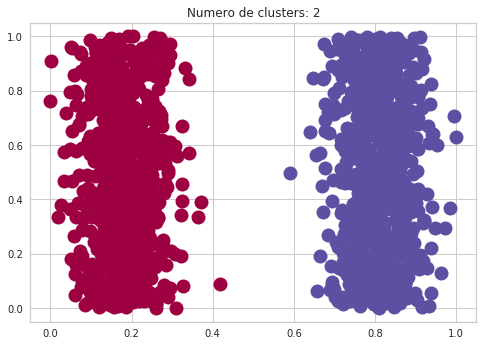

```python
apply_dbscan(df)
my_DBSCAN(0.2, 4, df)
```

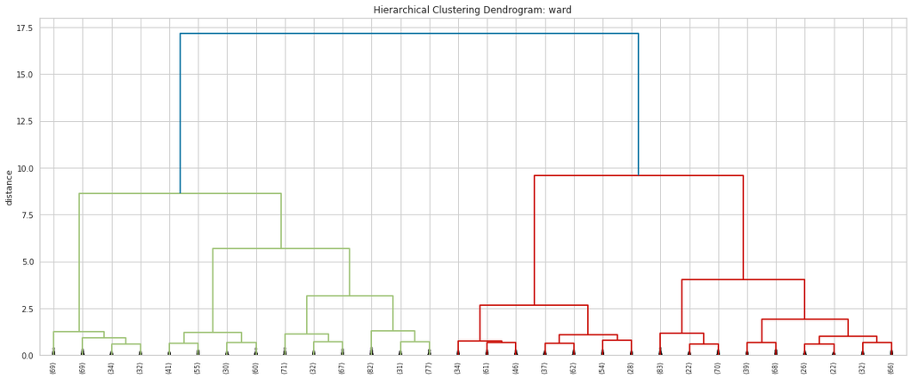

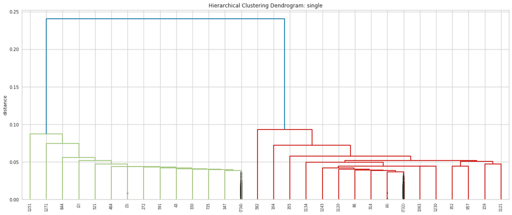

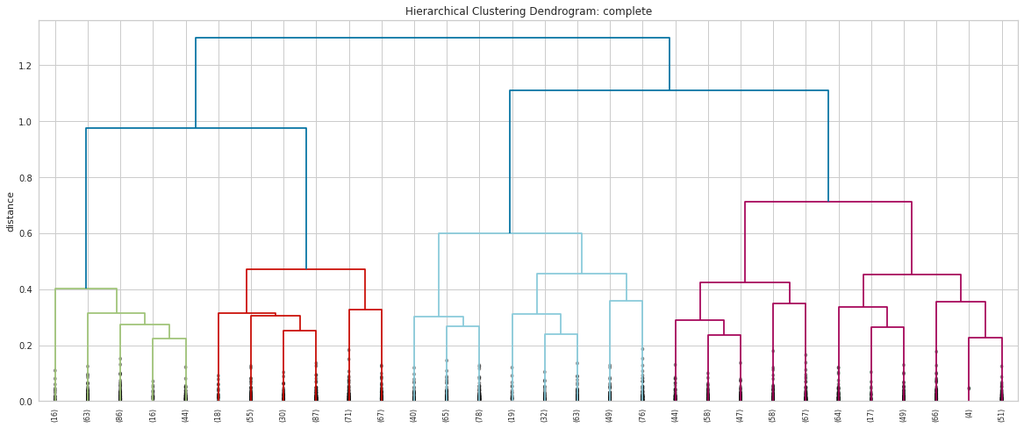

```python
test_all_hierarchy(df)
```

Como salida y comparación, podemos sacar algunas conclusiones importantes:

- K-Means ha podido agrupar adecuadamente (lo que antes no había sido capaz)
- DBSCAN refuerza el agrupamiento realizado por K-Means considerando que los grupos definidos han sido bastante iguales
- Tanto los dendrograma jerárquicos ward cuanto single ahora representan los 2 grupos principales - antes teníamos el comportamiento simplemente en el single.

## 3. Reducción de dimensionalidad: PCA y t-SNE (1 punto)

Al plantear un problema de clasificación con un dataset de más de tres atributos (dimensiones), no se puede realizar una visualización clásica del dataset para entender los datos. Por ello, uno de los usos de los métodos de reducción de dimensionalidad es transformar los datos de más de 4 dimensiones a 3 o menos para poder visualizarlos.

### 3 a. PCA

El [dataset Iris](https://es.wikipedia.org/wiki/Iris_flor_conjunto_de_datos) contiene 4 atributos sobre tres tipos de flores.

```python
iris = datasets.load_iris()
X = iris.data   # np.array con shape (150, 4)
y = iris.target # np.array con shape (150,)
```

Al exceder las 3 dimensiones necesitaremos más de una visualización para entender los datos.

Para solucionarlo, una alternativa es usar los [*pair plots*](http://seaborn.pydata.org/generated/seaborn.pairplot.html) que enfrentan pares de dimensiones para tratar de dar una visión global a partir de un [DataFrame](https://pandas.pydata.org/pandas-docs/stable/dsintro.html):

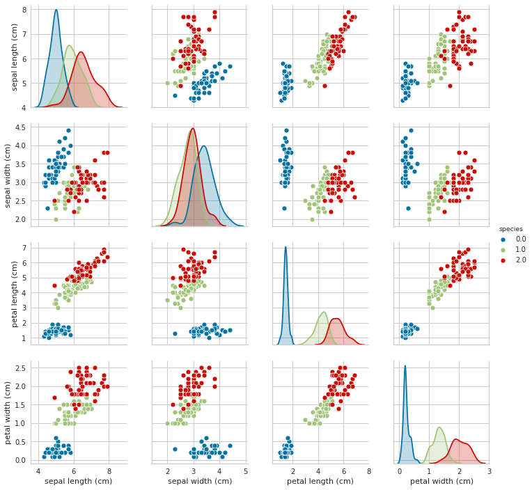

```python
# DataFrame
iris_df = pd.DataFrame(np.hstack([X, y.reshape(-1, 1)]), columns=iris.feature_names + ['species'])
sns.pairplot(iris_df, vars=iris.feature_names, hue="species")
```

Como alternativa a las múltiples gráficas que generan los gráficos pareados, se plantea utilizar una técnica de reducción de dimensionalidad para pasar de 4 dimensiones a 2. Nótese que gráficas como *longitud de pétalo* vs *anchura de pétalo* muestran cierta separabilidad (los 3 tipos de flores están aparentemente separados).

**Implementación:** realizar una reducción de dimensionalidad con PCA para pasar de 4 dimensiones a 2 y crear una visualización donde el color de los puntos dependa del tipo de flor a la que pertenece.

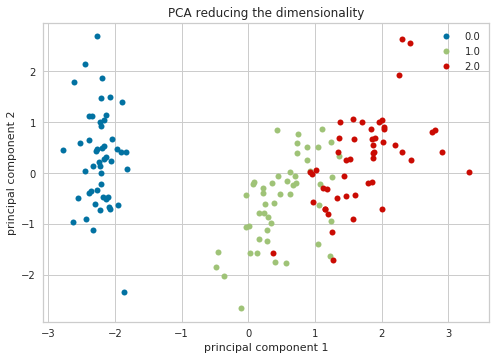

```python
from sklearn.preprocessing import StandardScaler
from sklearn.decomposition import PCA

def plot_by_species(final_df):
    groups = final_df.groupby('species')
    figure, axes = plt.subplots()
    axes.margins(0.05)
    for name, group in groups:
        axes.plot(group['principal component 1'], group['principal component 2'], marker='o', linestyle='', ms=6, label=name)
        axes.set_title("PCA reducing the dimensionality")
    axes.legend()
    plt.xlabel("principal component 1")
    plt.ylabel("principal component 2")
    plt.show()



class_label = pd.DataFrame(iris_df.iloc[:,-1])
class_label.columns = ['species']

iris_df = iris_df.iloc[:, :-1]

iris_df = StandardScaler().fit_transform(iris_df)

pca = PCA(n_components=2)
principalComponents = pca.fit_transform(iris_df)
principalDf = pd.DataFrame(data = principalComponents
             , columns = ['principal component 1', 'principal component 2'])

finalDfPCA = pd.concat([principalDf, class_label], axis = 1)
finalDfPCA.head()
plot_by_species(finalDfPCA)
```

**Análisis:** ¿El resultado de la reducción de dimensionalidad mantiene la separabilidad? ¿Era de esperar? ¿Por qué?

Sí, como demostrado en el gráfico, hemos logrado de mantener la separabilidad.

Para la PCA que realizamos aquí en el conjunto de datos del iris, 2 PC parecen ser suficientes para los propósitos de visualización. Por lo tanto, PCA no solo nos da la capacidad de visualizar los datos en una dimensión inferior, sino que también reduce el tiempo de cálculo de algunos algoritmos numéricos.

### 3 b. t-SNE (t-distributed Stochastic Neighbor Embedding)

El uso de técnicas de reducción de dimensionalidad es de gran utilidad cuando esta es muy alta. Por ejemplo, el [dataset Digits](http://scikit-learn.org/stable/auto_examples/classification/plot_digits_classification.html) contiene 1797 imágenes de números del 0 al 9, de 8 por 8 píxeles. Si se toma cada pixel como una dimensión, eso se traduce en que cada muestra tiene ¡64 dimensiones!

```python
digits = datasets.load_digits()
X = digits.data   # np.array con shape (1797, 64)
y = digits.target # np.array con shape (1797,)
```

Ejemplo de los 24 primeros dígitos de 8 por 8 píxeles junto a su etiqueta presentes en el dataset:

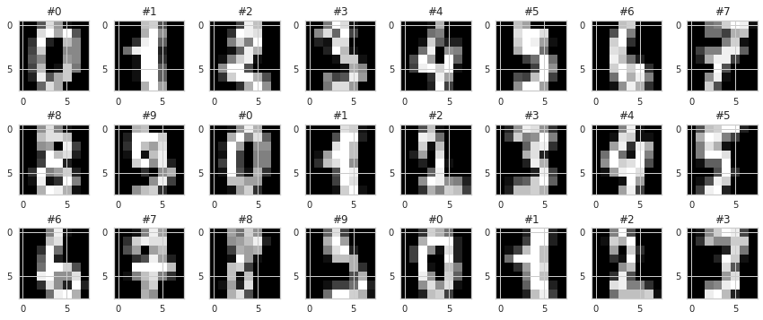

```python
fig, ax = plt.subplots(3, 8, figsize=(12, 5))
for i, axis in zip(range(24), ax.reshape(-1)):
    axis.imshow(X[i,:].reshape(8, 8), cmap='gray')
    axis.set_title('#{}'.format(y[i]))
plt.tight_layout()
```

Con un número tan elevado de dimensiones pierde sentido visualizar el dataset con un *pair plot* y aparecen otros peligos como la [maldición de la dimensionalidad](https://es.wikipedia.org/wiki/Maldici%C3%B3n_de_la_dimensi%C3%B3n). Para reducir su dimensión y así entender la estructura de los datos en alta dimensionalidad existen distintas alternativas con resultados muy distintos.

**Implementación:** realizar una reducción de dimensionalidad con PCA para pasar de 64 dimensiones a 2 y crear una visualización donde el color de los puntos dependa del dígito que pertenece.

```
1797 [0 1 2 ... 8 9 8]
```

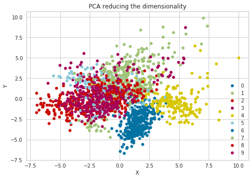

```python
def plot_by_target(final_df):
    groups = final_df.groupby('label')
    figure, axes = plt.subplots()
    axes.margins(0.05)
    for name, group in groups:
        axes.plot(group['x'], group['y'], marker='o', linestyle='', ms=6, label=name)
        axes.set_title("PCA reducing the dimensionality")
    axes.legend()
    plt.xlabel("X")
    plt.ylabel("Y")
    plt.show()


pca_digits = PCA(n_components=2)
X = StandardScaler().fit_transform(X)
principal_components_digits = pca_digits.fit_transform(X)
principalDfDigits = pd.DataFrame(data = principal_components_digits
             , columns = ['principal component 1', 'principal component 2'])
print(len(y), y)

finalDfDigitsPCA = pd.concat([principalDfDigits, pd.Series(y)], axis = 1)
finalDfDigitsPCA.columns = ['x','y','label']
finalDfDigitsPCA.head()
plot_by_target(finalDfDigitsPCA)
```

```
(1797, 64)
(1797, 2)
```

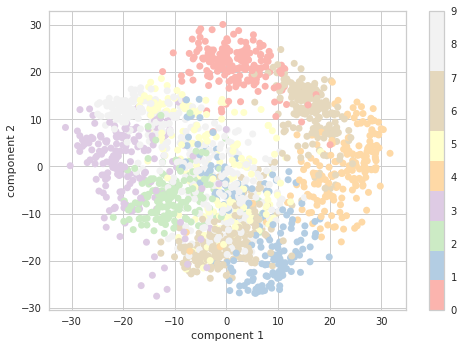

```python
# Implementacion más sencilla
pca = PCA(2)  # project from 64 to 2 dimensions
projected = pca.fit_transform(digits.data)
print(digits.data.shape)
print(projected.shape)

plt.scatter(projected[:, 0], projected[:, 1],
            c=digits.target, edgecolor='none', alpha=1.0,
            cmap=plt.cm.get_cmap('Pastel1', 10))
plt.xlabel('component 1')
plt.ylabel('component 2')
plt.colorbar();
```

**Análisis:** ¿El resultado de la reducción de dimensionalidad mantiene la separabilidad? ¿Era de esperar? ¿Por qué?

Recordando que los datos completos son una nube de puntos de 64 dimensiones, y estos puntos que vemos ahora son la proyección de cada punto de datos a lo largo de las direcciones con la mayor varianza.

Esencialmente, hemos encontrado el estiramiento y la rotación óptimos en el espacio de 64 dimensiones que nos permite ver el diseño de los dígitos en dos dimensiones. Obviamente, **no se observa la separabilidad** que veíamos antes en un data set con menos dimensiones.

El algoritmo [t-SNE](https://en.wikipedia.org/wiki/T-distributed_stochastic_neighbor_embedding) ideado por [van der Maaten y Hinton](https://lvdmaaten.github.io/tsne/) difiere de PCA en que no trata de maximizar la varianza explicada. Intuitivamente, t-SNE trata de que la vecindad de un punto en baja dimensionalidad sea la misma que la original. Partiendo de una localización aleatoria de cada punto, corrige su posición de forma iterativa tratando de minimizar la distancia a sus vecinos originales hasta converger.

Para ello, t-SNE dispone de diversos [parámetros](https://distill.pub/2016/misread-tsne/) que pueden modificar drásticamente el resultado. Por lo que se recomienda conocer su funcionamiento antes de aplicar la técnica.

**Implementación:** realizar una reducción de dimensionalidad con t-SNE para pasar de 64 dimensiones a 2 y crear una visualización donde el color de los puntos dependa del dígito que pertenece.

```
(1797, 64)
(1797, 2)
```

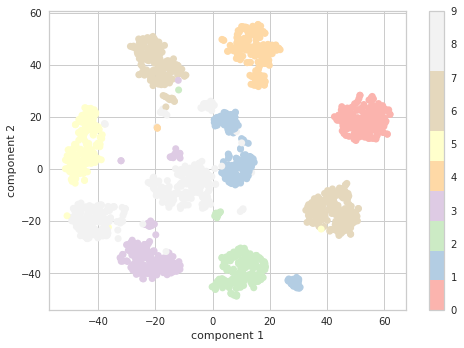

```python
from sklearn.manifold import TSNE

tsne = TSNE(learning_rate=150)
transformed = tsne.fit_transform(digits.data)

print(digits.data.shape)
print(transformed.shape)

plt.scatter(transformed[:, 0], transformed[:, 1],
            c=digits.target, edgecolor='none', alpha=1.0,
            cmap=plt.cm.get_cmap('Pastel1', 10))
plt.xlabel('component 1')
plt.ylabel('component 2')
plt.colorbar();
```

**Análisis:** ¿El resultado de la reducción de dimensionalidad mantiene la separabilidad? ¿Era de esperar? ¿Por qué?

Sí, el resultado aquí **mantiene casi que perfectamente la separabilidad** - considerando que el termino casi es por cuenta de outliers que aparecen. Creo que era de esperar que la solución fuera más clara aquí, especialmente porque TSNE La intenta descontaminar las relaciones entre vecinos en datos de alta dimensión. En términos sencillos: t-SNE intenta comprender la estructura subyacente - lo hace priorizando los puntos vecinos. PCA no entiende lo que está pasando, no ve que los puntos son en realidad una línea que se ha acumulado.

## 4. Aplicación: Agrupación de documentos (3 puntos)

### 4 a. Carga y limpieza de datos

En este problema se utilizará el dataset [*20 news group*](https://archive.ics.uci.edu/ml/machine-learning-databases/20newsgroups-mld/20newsgroups.data.html), con 20 categorías de textos, de los cuales se seleccionarán 3. El objetivo es encontrar grupos de textos (preferiblemente de la misma categoría) a través de sus palabras.

El primer apartado consiste en cargar el dataset y limpiar los datos (tarea que normalmente tiene una carga entre el 70 y 80% del tiempo), en este caso los textos.

```python
data = datasets.fetch_20newsgroups(categories=['rec.autos', 'rec.sport.baseball', 'soc.religion.christian'])
texts, targets = data['data'], data['target']
```

Donde `texts` es una lista con los artículos y `targets` es un vector con el índice de la categoría a la que pertenece cada texto.

La limpieza de texto debe convertir:

```python
print(data['data'][1])
```

```
From: aas7@po.CWRU.Edu (Andrew A. Spencer)
Subject: Re: Too fast
Organization: Case Western Reserve University, Cleveland, OH (USA)
Lines: 25
Reply-To: aas7@po.CWRU.Edu (Andrew A. Spencer)
NNTP-Posting-Host: slc5.ins.cwru.edu


In a previous article, wrat@unisql.UUCP (wharfie) says:

>In article <1qkon8$3re@armory.centerline.com> jimf@centerline.com (Jim Frost) writes:
>>larger engine.  That's what the SHO is -- a slightly modified family
>>sedan with a powerful engine.  They didn't even bother improving the
>>*brakes.*
>
>	That shows how much you know about anything.  The brakes on the
>SHO are very different - 9 inch (or 9.5? I forget) discs all around,
>vented in front.  The normal Taurus setup is (smaller) discs front,
>drums rear.

one i saw had vented rears too...it was on a lot.
of course, the sales man was a fool..."titanium wheels"..yeah, right..
then later told me they were "magnesium"..more believable, but still
crap, since Al is so m uch cheaper, and just as good....


i tend to agree, tho that this still doesn't take the SHO up to "standard"
for running 130 on a regular basis.  The brakes should be bigger, like
11" or so...take a look at the  ones on the Corrados.(where they have
braking regulations).

DREW
```

En algo muy parecido a:

`In previous article UUCP wharfie says In article centerline com com Jim Frost writes larger engine That's what the SHO is slightly modified family sedan with powerful engine They didn't even bother improving the *brakes That shows how much you know about anything The brakes on the SHO are very different inch or forget discs all around vented in front The normal Taurus setup is smaller discs front drums rear one saw had vented rears too it was on lot of course the sales man was fool titanium wheels yeah right then later told me they were magnesium more believable but still crap since Al is so uch cheaper and just as good tend to agree tho that this still doesn't take the SHO up to standard for running 130 on regular basis The brakes should be bigger like 11 or so take look at the ones on the Corrados where they have braking regulations DREW`

**Implementación:** limpia los textos de entrada:

- Elimina las líneas de encabezado.
- Los signos de puntuación.
- Los corchetes, paréntesis y angulares.
- Los saltos de línea.
- Exclamaciones e interrogaciones.
- Los tokens e-mails y de longitud 1.
- Los espacios en blanco consecutivos.

```python
import re
import string
from email_split import email_split
```

```python
remove = ['headers']#, 'footers', 'quotes']
categories = ['rec.autos', 'rec.sport.baseball', 'soc.religion.christian']
data_clean = datasets.fetch_20newsgroups(categories=categories, remove=remove)
texts_clean, targets_clean = data_clean['data'], data_clean['target']


regex_email = re.compile(r'[\S\.-]+@[\w\.-]+')


def remove_domain(m):
    domain = email_split(m).domain
    return domain[domain.index('.') + 1 :]

def remove_single_char(text):
    splited = text.split()
    joined = ''

    for s in splited:
        if len(s) > 1 :
            joined += ' ' + s
    return joined


def preprocessing(text):
    splited = text.split()
    joined = ''
    for s in splited:
        if regex_email.match(s):
            joined += ' ' + remove_domain(s)
        else:
            if len(s) > 1 :
                joined += ' ' + s

    return remove_single_char(" ".join("".join([" " if ch in string.punctuation and ch !='\'' and ch != '*' else ch for ch in joined]).split()))


print(preprocessing(data_clean['data'][1]))
```

```
 In previous article UUCP wharfie says In article centerline com com Jim Frost writes larger engine That's what the SHO is slightly modified family sedan with powerful engine They didn't even bother improving the *brakes That shows how much you know about anything The brakes on the SHO are very diff…
```

### 4 b. Conversión de textos a vectores

Para encontrar grupos entre los textos, es necesario convertir cada texto en un vector. Existen multitud de maneras de hacerlo, una de ellas es aplicar [TF-IDF](https://en.wikipedia.org/wiki/Tf%E2%80%93idf) con scikit-learn [TfidfVectorizer](http://scikit-learn.org/stable/modules/generated/sklearn.feature_extraction.text.TfidfVectorizer.html). Transformando la lista de textos en una [matriz dispersa](https://docs.scipy.org/doc/scipy/reference/sparse.html) con tantas filas como artículos y tantas columnas como palabras.

**Implementación:** transforma los textos a vectores con TF-IDF. Para reducir el número de columnas en la matriz evita las *stop words* en inglés y convierte los textos a minúsculas.

```python
import nltk
from nltk.corpus import stopwords
from sklearn.feature_extraction.text import TfidfVectorizer

vectorizer = TfidfVectorizer(min_df=2, ngram_range=(1, 2)
                             , stop_words='english', max_features= 10000
                             , strip_accents='unicode' , norm='l2'
                            , lowercase='true')



tfidf_matrix = vectorizer.fit_transform(texts_clean)
tfidf_matrix.shape
```

```
(1790, 10000)
```

### 4 c. Reducción de dimensionalidad

Para visualizar y encontrar los grupos, se reducirá la dimensionalidad de la matriz anterior. De tal forma que el número de columnas se reducirá a 2 (el número de filas se mantiene, ya que cada fila es un documento).

**Implementación:** utiliza t-SNE para reducir la dimensionalidad de *n* columnas (palabras) a 2 dimensiones. Utiliza un tamaño de perplejidad alto para aumentar la vecindad (en torno a 100).

```python
tsne_model = TSNE(n_components=2, learning_rate=90, verbose=1, random_state=0, angle=.99)
tsne_lda = tsne_model.fit_transform(tfidf_matrix.toarray())
```

```
[t-SNE] Computing 91 nearest neighbors...
[t-SNE] Indexed 1790 samples in 0.357s...
[t-SNE] Computed neighbors for 1790 samples in 46.469s...
[t-SNE] Computed conditional probabilities for sample 1000 / 1790
[t-SNE] Computed conditional probabilities for sample 1790 / 1790
[t-SNE] Mean sigma: 0.521974
[t-SNE] KL divergence after 250 iterations with early exaggeration: 132.895248
[t-SNE] KL divergence after 1000 iterations: 2.783014
```

**Implementación:** visualiza mediante un scatter plot los puntos en 2 dimensiones con un color para cada clase.

```python
print(len(np.unique(targets_clean)))
```

```
3
```

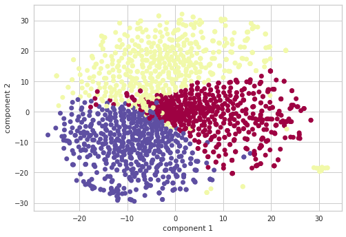

```python
plt.scatter(tsne_lda[:, 0], tsne_lda[:, 1],
            c=targets_clean, edgecolor='none', alpha=1.0,
            cmap=plt.cm.get_cmap('Spectral', 10))
plt.xlabel('component 1')
plt.ylabel('component 2')
```

### 4 d. Encuentra los grupos de artículos con distintos algoritmos

**Implementación:** utiliza *k-means* (con *k=3*) para tratar de encontrar los 3 grupos de artículos y visualiza el resultado.

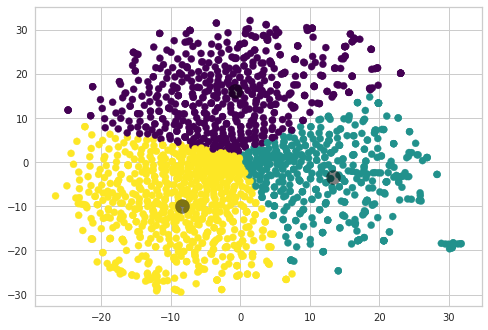

```python
X4d = tsne_lda

km = KMeans(n_clusters=3)
km = km.fit(X4d)
y4d = km.predict(X4d)

plt.scatter(X4d[:, 0], X4d[:, 1], c=y4d, s=50, cmap='viridis')

centers = km.cluster_centers_
plt.scatter(centers[:, 0], centers[:, 1], c='black', s=200, alpha=0.5)
```

**Análisis:** ¿Ha localizado los 3 grupos originales? (el color no tiene porque coincidir, solo nos importa la forma) ¿Por qué?

Sí, he sido capaz de localizar y separar bien los 3 colores distintos como queda claro en la imagen arriba.

Para agrupar los textos tratando de situar los centroides en las regiones más densas, [Mean-Shift](http://scikit-learn.org/stable/modules/generated/sklearn.cluster.MeanShift.html) sigue un camino desde cualquier punto del espacio guiándose por la densidad de puntos hasta alcanzar un máximo local (dentro de su *bandwidth*).

**Implementación:** utiliza *Mean-Shift* (variando en *bandwidth*) hasta encontrar 3 grupos y visualiza el resultado.

```
Numero de clusters estimado: 3
```

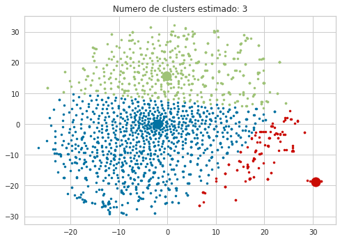

```python
from sklearn.cluster import MeanShift, estimate_bandwidth
from itertools import cycle

## Podría tener usado una aproximacion como: bandwidth = estimate_bandwidth(tsne_lda, quantile=0.8, n_samples=10000)
X = tsne_lda
ms = MeanShift(bandwidth=9, bin_seeding=True)
ms.fit(X)
labels = ms.labels_
cluster_centers = ms.cluster_centers_

labels_unique = np.unique(labels)
n_clusters_ = len(labels_unique)
print("Numero de clusters estimado: %d" % n_clusters_)


plt.figure(1)
plt.clf()

colors = cycle('bgrcmykbgrcmykbgrcmykbgrcmyk')
for k, col in zip(range(n_clusters_), colors):
    my_members = labels == k
    cluster_center = cluster_centers[k]
    plt.plot(X[my_members, 0], X[my_members, 1], col + '.')
    plt.plot(cluster_center[0], cluster_center[1], 'o', markerfacecolor=col,
             markeredgecolor='k', markersize=14)
plt.title('Numero de clusters estimado: %d' % n_clusters_)
plt.show()
```

**Análisis:** ¿Ha localizado los 3 grupos originales? (el color no tiene porque coincidir, solo nos importa la forma) ¿Por qué?